# Homework2

Anish Ravindran

2024-01-26

Name: Anish Ravindran  
uteid: ar76454  
github link: “https://github.com/AnishRavi5/Homework2”

## Problem 1

### Part A

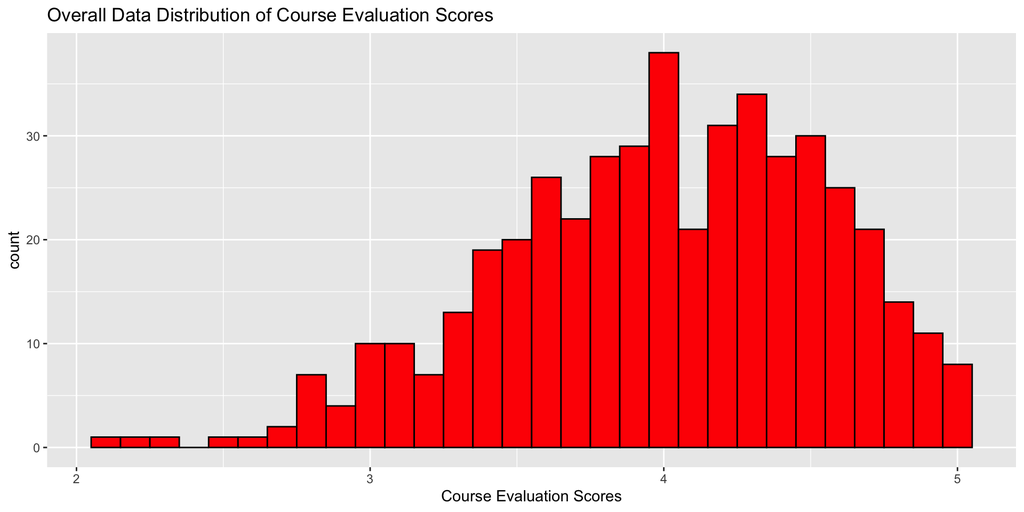

The histogram of the course evaluation scores shows a normal distribution some left skew. The median evaluation score is a 4 and 75 percent of courses were rated above 3.6 showing that a majority of the courses in the college are rated highly. There however is some left skew showing some classes having a low rating between 2 and 2.5 and no class in the college was rated below a 2.1.

### Part B

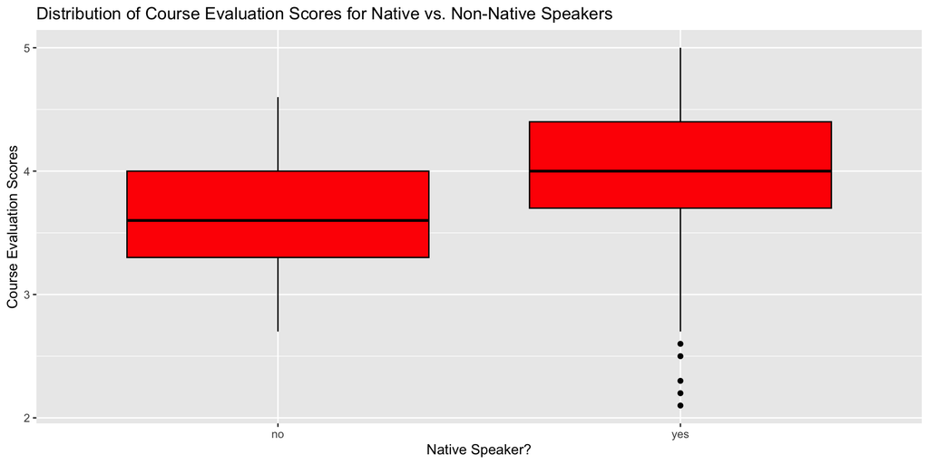

The plots comparing the evaluation scores for native speakers versus non-native speakers show us that professors who are native speakers tend to have higher course evaluation scores. The professors who are native speakers have a median evaluation score of 4 while non-native speakers have an evaluation score of 3.6. The median, upper quartile, lower quartile, and max are all higher for the native speakers but there are outliers that have low course evaluation scores that exist giving the native speaking professors the lowest 5 scores.

### Part C

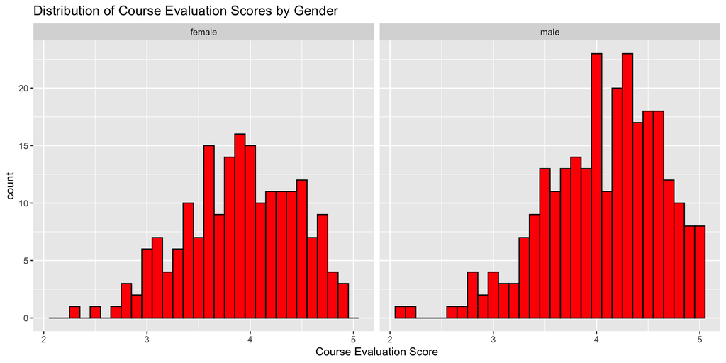

The histograms that compare the distributions of the course evaluation scores for the male and female teachers shows us that students on avergare tend to like the male teachers more as the median score was higher for male teachers. There were also more male teachers than women teachers leading to more outliers for the male teachers as there are some male teachers who have the lowest overall scores and also the highest overall scores.

### Part D

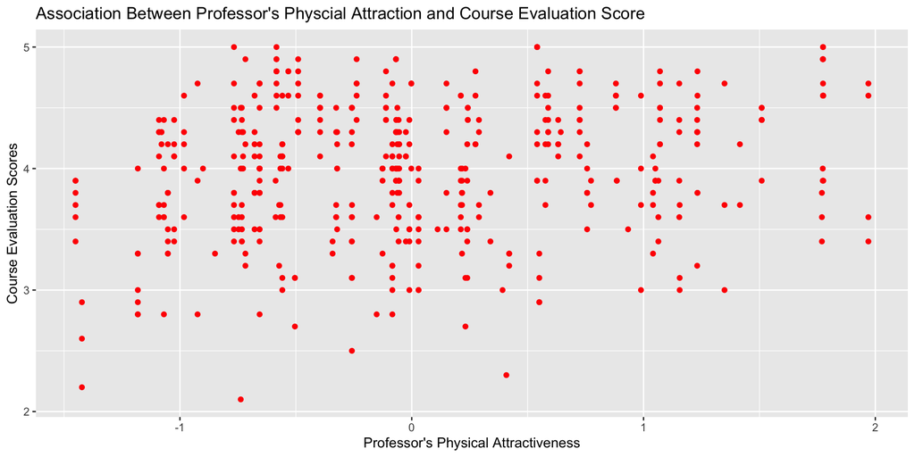

## Problem 2

### Plot A

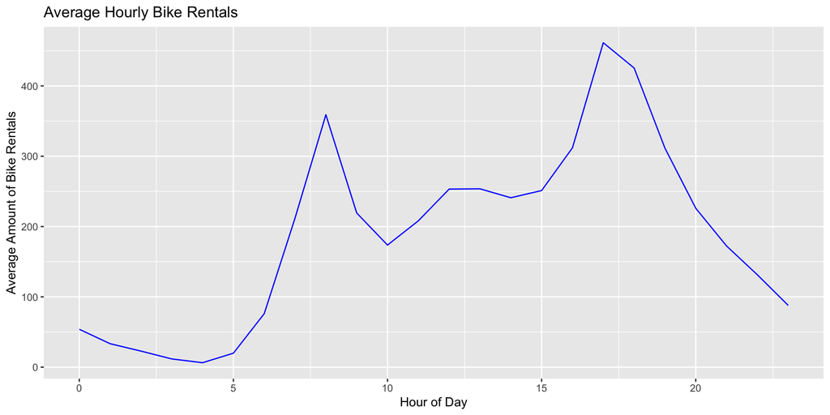